# IODS course project

# 3. Logistic regression

This week I performed logistic regression analysis. Below you can find the analysis that was performed, more information about the data that was analyzed and the results I got.

```r
date()
```

```
## [1] "Wed Dec 02 15:17:09 2020"
```

Data was loaded from [link](https://archive.ics.uci.edu/ml/machine-learning-databases/00320/) (student.zip file) More information can be found [here](https://archive.ics.uci.edu/ml/datasets/Student+Performance).

Data was described in the web page :“This data approach student achievement in secondary education of two Portuguese schools. The data attributes include student grades, demographic, social and school related features and it was collected by using school reports and questionnaires.” There were two datasets regarding performance in two distinct subjects: Mathematics (mat) and Portuguese language (por). Those datasets were joined together in data wrangling exercise. I am using Reijo Sund´s version of the data in my calculation and it consists of 370 observations of 51 variables. Names of the variables are seen below.

Accessing useful libraries at first:

```r
library(tidyr); library(dplyr); library(ggplot2)
alc_consump <- read.table("~/R/IODS-course/IODS-project/Data/pormath.txt", sep = ",", header=TRUE)
glimpse(alc_consump)
```

```
## Rows: 370
## Columns: 51
## $ school     <chr> "GP", "GP", "GP", "GP", "GP", "GP", "GP", "GP", "GP", "G...
## $ sex        <chr> "F", "F", "F", "F", "F", "F", "F", "F", "F", "F", "F", "...
## $ age        <int> 15, 15, 15, 15, 15, 15, 15, 15, 15, 15, 15, 15, 15, 15, ...
## $ address    <chr> "R", "R", "R", "R", "R", "R", "R", "R", "R", "U", "U", "...
## $ famsize    <chr> "GT3", "GT3", "GT3", "GT3", "GT3", "GT3", "GT3", "LE3", ...
## $ Pstatus    <chr> "T", "T", "T", "T", "T", "T", "T", "T", "T", "A", "A", "...
## $ Medu       <int> 1, 1, 2, 2, 3, 3, 3, 2, 3, 3, 4, 1, 1, 1, 1, 1, 2, 2, 2,...
## $ Fedu       <int> 1, 1, 2, 4, 3, 4, 4, 2, 1, 3, 3, 1, 1, 1, 2, 2, 1, 2, 3,...
## $ Mjob       <chr> "at_home", "other", "at_home", "services", "services", "...
## $ Fjob       <chr> "other", "other", "other", "health", "services", "health...
## $ reason     <chr> "home", "reputation", "reputation", "course", "reputatio...
## $ guardian   <chr> "mother", "mother", "mother", "mother", "other", "mother...
## $ traveltime <int> 2, 1, 1, 1, 2, 1, 2, 2, 2, 1, 1, 3, 1, 1, 1, 1, 3, 1, 2,...
```

[output cut: 38 more lines]

```r
alc_consump$sex <- factor(alc_consump$sex) # Making sex a factor
```

I chose 4 different variables: sex, grades, absences and freetime. My hypotheses are:

1. Male sex has higher alcohol consumption compared to females.
2. Lower grades at school result in greater alcohol consumption.
3. More absences at school can be explained by higher alcohol consumption.
4. More freetime can lead to higher alcohol consumption.

#### Graphical and numerical overview of the chosen variables

##### Sex

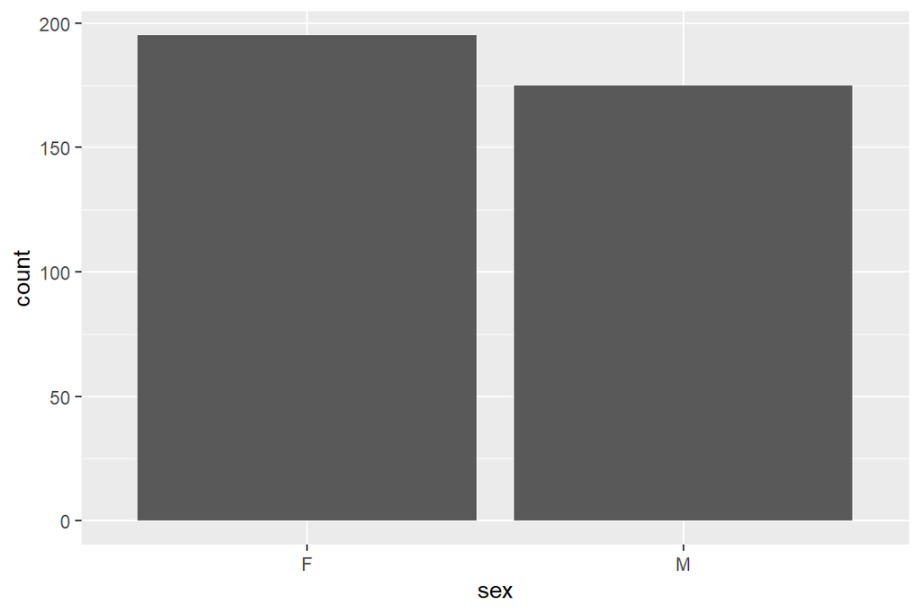

```r
g1 <- ggplot(alc_consump, aes(x=sex)) #bar plot of sex variable
g1 + geom_bar()
```

```r
alc_consump %>% group_by(sex, high_use)%>% summarise(count = n()) #tabular summary of the relationship between sex and high use
```

```
## # A tibble: 4 x 3
## # Groups:   sex [2]
##   sex   high_use count
##   <fct> <lgl>    <int>
## 1 F     FALSE      154
## 2 F     TRUE        41
## 3 M     FALSE      105
## 4 M     TRUE        70
```

There are 195 females and 175 males in the data. From the table above we can see that there are more high alcohol using students in males (70) that in females (41), as I assumed in my first hypothesis.

##### Grades

Next we will see what is the relationship between grades and alcohol consumption. From the bar plot we can see that the distribution of the grades is more on the right side, so most of the grades are good (>10).

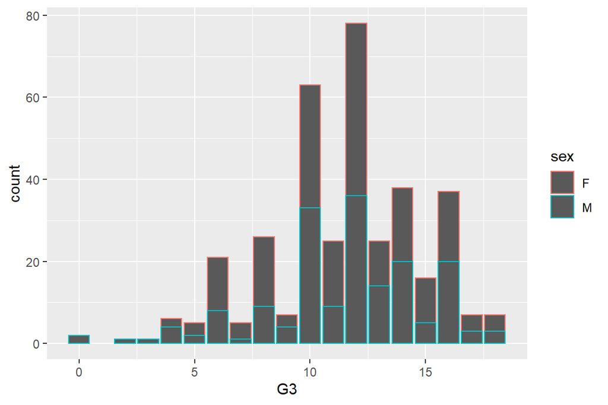

```r
g2 <- ggplot(alc_consump, aes(x=G3, col=sex)) #bar plot of grades
g2 + geom_bar()
```

```r
alc_consump %>% group_by(sex, high_use) %>% summarise(count = n(), mean_grade = mean(G3))
```

```
## # A tibble: 4 x 4
## # Groups:   sex [2]
##   sex   high_use count mean_grade
##   <fct> <lgl>    <int>      <dbl>
## 1 F     FALSE      154       11.4
## 2 F     TRUE        41       11.8
## 3 M     FALSE      105       12.3
## 4 M     TRUE        70       10.3
```

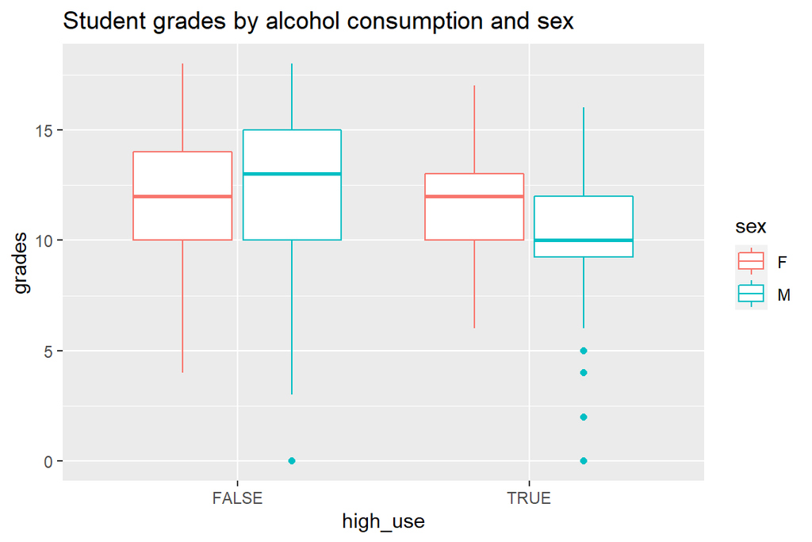

```r
g3 <- ggplot(alc_consump, aes(x = high_use, y = G3, col=sex))#box plot of student grades and high use
g3 + geom_boxplot() + ylab("grades") +ggtitle("Student grades by alcohol consumption and sex")
```

Mean grades in female group don´t differ between high and low alcohol users. But in male group, there is difference between mean grades and it is lower in high alcohol users, which I expected. I also thought that this would be seen in females too.